# Minería de Datos

Clase 12: Inferencia y Estructura en Tablas de Contingencia

Departamento de Estadística, Sede Bogotá

## Conexión con el recorrido del curso

Todo lo visto hasta hoy forma parte de una misma cadena analítica dentro del pipeline KDD.

Clases 2-3Recolección (scraping)

Clases 4-5Bases de datos (SQL)

Clases 6-9EDA y visualización

Clase 10Viz interactiva

Clase 11Shiny y dashboards

Clase 12Inferencia categórica

En las clases anteriores aprendimos a explorar relaciones con Cramér’s V, Phi y correlaciones. Hoy profundizamos en la **inferencia formal** sobre esas relaciones: cuándo son reales, cuándo cambian entre grupos y cómo medirlas con rigor.

## Tablas de contingencia en el KDD

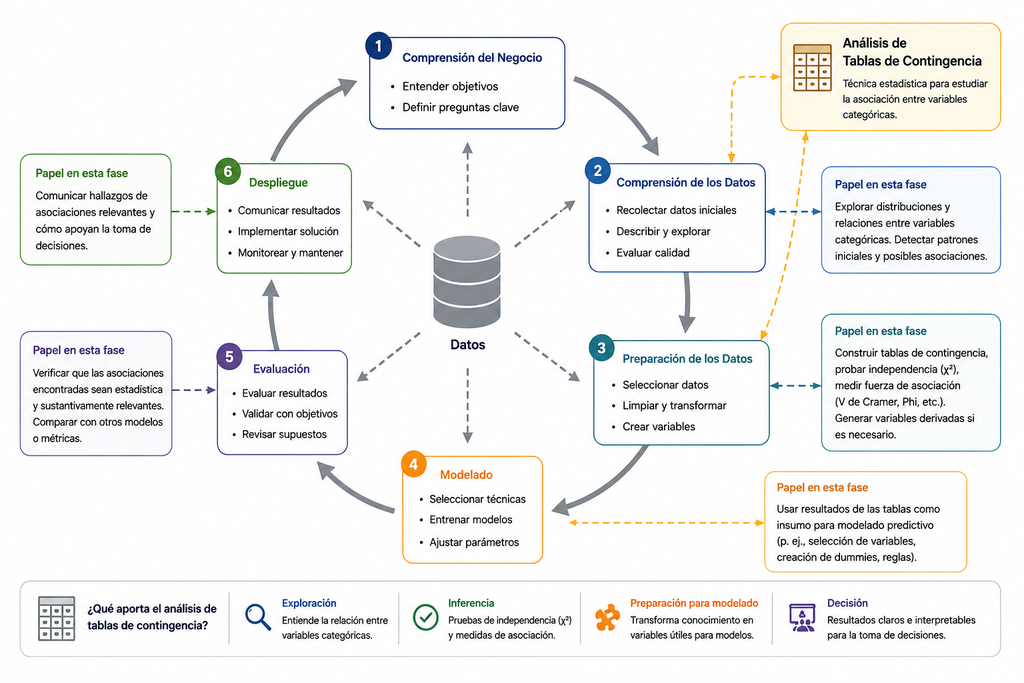

## Panorama de la clase

#### Esquemas de muestreo

Poisson, Multinomial y Producto-Multinomial.

#### Pruebas de independencia

Chi-cuadrado de Pearson y razón de verosimilitudes para evaluar asociación.

#### Acuerdo y correlación

Kappa de Cohen y correlaciones latentes para variables ordinales.

#### Paradoja de Simpson

Colapsibilidad y confusión en tablas tridimensionales.

Sección 1 de 10

## Esquemas de Muestreo en Tablas de Contingencia

El diseño del estudio determina la distribución de los conteos y las restricciones válidas de la tabla. Confundir los esquemas lleva a inferencias incorrectas.

## Tres esquemas fundamentales

En una tabla de contingencia $I \times J$, los conteos $n_{ij}$ pueden originarse de tres esquemas. Cada uno impone restricciones distintas sobre los totales de la tabla.

#### Poisson

n aleatorio

Cada $n_{ij}$ es independiente. El total $n$ no se fija antes del estudio.

Registros administrativos, vigilancia epidemiológica.

#### Multinomial

n fijo

El total $n$ se fija antes de recolectar. Los conteos siguen una distribución multinomial conjunta.

Encuestas transversales, muestras aleatorias únicas.

#### Producto-Multinomial

n<sub>i+</sub> fijos

Los totales de fila $n_{i+}$ son fijos por diseño. Dentro de cada fila, distribución multinomial independiente.

Estudios de casos y controles, experimentos estratificados.

## Esquema de Poisson

n aleatorio

Cada $n_{ij}$ es una variable aleatoria **independiente**:

$$n_{ij} \sim \text{Poisson}(\mu_{ij})$$

El total $n = \sum_{ij} n_{ij}$ no está fijo de antemano.

Ejemplo práctico

Accidentes viales en Bogotá (un mes). El total **no se fijó**: surgió del registro.

|  | Diurna | Nocturna | Total |
| --- | --- | --- | --- |
| Urbana | 143 | 98 | 241 |
| Rural | 37 | 54 | 91 |
| Total | 180 | 152 | 332 |

El 332 no fue planeado: es la suma de eventos observados.

## Esquema Multinomial

n fijo

El vector $(n_{11}, \ldots, n_{IJ})$ sigue una distribución multinomial:

$$P = \frac{n!}{\prod_{ij} n_{ij}!} \prod_{ij} \pi_{ij}^{n_{ij}}, \quad \sum_{ij}\pi_{ij}=1$$

El total $n$ se fija antes de recolectar los datos.

Ejemplo práctico

Se encuestan exactamente 1.000 personas y se clasifica cada una por nivel educativo y satisfacción laboral. El total 1.000 **es fijo**; la distribución entre celdas es aleatoria.

|  | Satisfecho | Insatisfecho | Total |
| --- | --- | --- | --- |
| Universitario | 312 | 88 | 400 |
| Bachillerato | 274 | 126 | 400 |
| Primaria | 98 | 102 | 200 |
| Total | 684 | 316 | 1.000 |

## Esquema Producto-Multinomial

n<sub>i+</sub> fijos

Los totales de fila $n_{i+}$ son fijos por diseño. Dentro de cada fila, distribución multinomial independiente:

$$\pi_{j \mid i} = \frac{\pi_{ij}}{\pi_{i+}}, \quad \sum_j \pi_{j \mid i} = 1$$

Cada fila es una subpoblación con muestra independiente.

Ejemplo práctico

Se seleccionan exactamente 200 casos (dengue) y 200 controles (sin dengue). Dentro de cada grupo se registra la exposición a factores de riesgo. Los totales de fila **están fijos**.

|  | Expuesto | No expuesto | Total |
| --- | --- | --- | --- |
| Dengue (caso) | 134 | 66 | 200 |
| Sin dengue (control) | 78 | 122 | 200 |
| Total | 212 | 188 | 400 |

Los totales de fila (200 y 200) fueron fijados por diseño; el total de columnas es aleatorio.

Casos de uso: estudios de casos y controles, experimentos estratificados.

## Comparación de los tres esquemas

| Característica | Poisson | Multinomial | Prod.-Multinomial |
| --- | --- | --- | --- |
| Total general $n$ | Aleatorio | Fijo | Fijo |
| Totales de fila | Aleatorios | Aleatorios | Fijos |
| Independencia entre celdas | Sí | No (suma a $n$) | No (suma a $n_{i+}$) |
| Diseño típico | Registros administrativos | Encuesta transversal | Casos y controles |
| Parámetros de interés | $\mu_{ij}$ | $\pi_{ij}$ | $\pi_{j \mid i}$ |

Para las pruebas de independencia, los tres esquemas conducen al mismo estadístico Chi-cuadrado. La distinción importa para la interpretación y los parámetros estimados.

## El mismo $\chi^2$: Poisson

Poisson

**$H_0$:** $\mu_{ij} = \mu_{i+} \cdot \mu_{+j} / n$ para todo $i,j$

**Pregunta:** ¿Las tasas de ocurrencia de cada celda son consistentes con independencia entre filas y columnas?

**Interpretación del rechazo:** existe asociación entre los dos factores en la población de donde provienen los registros. No implica causalidad ni dirección.

Ejemplo: si se rechaza $H_0$ en accidentes viales por zona y jornada, concluimos que la jornada nocturna no ocurre igual en zonas urbanas y rurales.

## El mismo $\chi^2$: Multinomial

Multinomial

**$H_0$:** $\pi_{ij} = \pi_{i+} \cdot \pi_{+j}$ para todo $i,j$

**Pregunta:** ¿La probabilidad de caer en la celda $(i,j)$ se puede descomponer como el producto de las probabilidades marginales?

**Interpretación del rechazo:** las variables de clasificación están asociadas en la población muestreada. La proporción conjunta no se explica por las marginales.

Ejemplo: en la encuesta de 1.000 personas, nivel educativo y satisfacción laboral no son independientes; conocer el nivel educativo cambia la distribución de satisfacción.

## El mismo $\chi^2$: Prod.-Multinomial

Prod.-Multinomial

**$H_0$:** $\pi_{j \mid i} = \pi_{+j}$ para todo $i,j$

**Pregunta:** ¿La distribución condicional de las columnas es la misma en todas las filas? (homogeneidad de proporciones)

**Interpretación del rechazo:** las distribuciones condicionales difieren entre grupos. Se habla de *falta de homogeneidad*, no de independencia en sentido estricto.

Ejemplo: en el estudio de dengue, casos y controles tienen proporciones de exposición distintas; el factor de riesgo se distribuye de manera diferente en cada grupo.

## Ejemplo 1: Regimen vs Región

```r
# Conteos de afiliación al SGSSS por región y régimen (datos ilustrativos)
tabla <- matrix(
  c(340, 210, 180,
    150, 380, 270,
    80,  120, 420),
  nrow = 3, byrow = TRUE,
  dimnames = list(
    Region    = c("Andina", "Caribe", "Pacífico"),
    Regimen   = c("Contributivo", "Subsidiado", "No afiliado")
  )
)
addmargins(tabla)
```

```
          Regimen
Region     Contributivo Subsidiado No afiliado  Sum
  Andina            340        210         180  730
  Caribe            150        380         270  800
  Pacífico           80        120         420  620
  Sum               570        710         870 2150
```

El total general (2.150) no fue fijo antes de recolectar los datos: es un registro administrativo. El esquema apropiado es **Poisson**. Si hubiera encuestado exactamente 2.150 personas, sería **multinomial**.

Sección 2 de 10

## Pruebas de Independencia: X² y G²

¿Existe asociación entre dos variables categóricas? La prueba Chi-cuadrado de Pearson y la razón de verosimilitudes responden esta pregunta con enfoques distintos.

## ¿Qué significa independencia estadística?

Definición: Independencia en tablas de contingencia

Dos variables $X$ e $Y$ son independientes si y solo si:
$$\pi_{ij} = \pi_{i+} \cdot \pi_{+j} \quad \text{para todo } i, j$$
Bajo independencia, las frecuencias esperadas son:
$$\hat{\mu}_{ij} = \frac{n_{i+} \cdot n_{+j}}{n}$$

La hipótesis nula $H_0$ afirma independencia. Rechazarla indica que la distribución conjunta no se factoriza como el producto de las marginales.

## Chi-cuadrado de Pearson ($\chi^2$)

Estadístico X² de Pearson

$$\chi^2 = \sum_{i=1}^{I}\sum_{j=1}^{J} \frac{(n_{ij} - \hat{\mu}_{ij})^2}{\hat{\mu}_{ij}}$$
Bajo $H_0$, $\chi^2 \xrightarrow{d} \chi^2_{(I-1)(J-1)}$ cuando $n \to \infty$.

- $n_{ij}$: frecuencia observada en la celda $(i, j)$.
- $\hat{\mu}_{ij}$: frecuencia esperada bajo independencia.
- $(I-1)(J-1)$: grados de libertad de la distribución asintótica.
- Un valor grande de $X^2$ indica desajuste respecto a la independencia.

## Razón de verosimilitudes (G²)

Estadístico G² (log-likelihood ratio)

$$G^2 = 2\sum_{i=1}^{I}\sum_{j=1}^{J} n_{ij} \ln\!\left(\frac{n_{ij}}{\hat{\mu}_{ij}}\right)$$
Bajo $H_0$, $G^2 \xrightarrow{d} \chi^2_{(I-1)(J-1)}$ cuando $n \to \infty$.

#### Ventaja de G²

> Tiene la propiedad aditiva: para tablas anidadas, $G^2$ total es la suma de los $G^2$ parciales. Esto facilita la comparación de modelos log-lineales.

#### Ventaja de $\chi^2$

Converge más rápido a la distribución chi-cuadrado en muestras moderadas. Preferido cuando hay celdas con frecuencias esperadas entre 5 y 20.

## Supuestos de ambas pruebas

Alerta: Supuestos críticos

- Las observaciones deben ser **independientes** entre sí.
- Cada observación pertenece a **exactamente una** celda.
- Las frecuencias esperadas $\hat{\mu}_{ij}$ deben ser **mayores a 5** en al menos el 80% de las celdas (regla de Cochran).
- Ninguna celda debe tener $\hat{\mu}_{ij} < 1$.

Cuando las frecuencias esperadas son muy pequeñas, se recomienda la prueba exacta de Fisher (para tablas 2×2) o combinar categorías con sentido sustantivo.

## Ejemplo 2: Nivel de estudios y acceso a internet

```r
# Municipios de Colombia: nivel educativo vs acceso a internet (datos ilustrativos)
tab <- matrix(
  c(180, 40,
    210, 95,
    60,  150),
  nrow = 3, byrow = TRUE,
  dimnames = list(
    Educacion = c("Sin bachillerato", "Bachillerato", "Superior"),
    Internet  = c("Sin acceso", "Con acceso")
  )
)
prueba <- chisq.test(tab, correct = FALSE)
prueba
```

```
    Pearson's Chi-squared test

data:  tab
X-squared = 141.09, df = 2, p-value < 2.2e-16
```

## Interpretación del ejemplo

```r
# Frecuencias esperadas
round(prueba$expected, 1)
```

```
                  Internet
Educacion          Sin acceso Con acceso
  Sin bachillerato      134.7       85.3
  Bachillerato          186.7      118.3
  Superior              128.6       81.4
```

```r
# Residuos estandarizados
round(prueba$stdres, 2)
```

```
                  Internet
Educacion          Sin acceso Con acceso
  Sin bachillerato       7.49      -7.49
  Bachillerato           3.57      -3.57
  Superior             -11.49      11.49
```

Ejemplo: Lectura de resultados

Un residuo estandarizado mayor a $|2|$ señala una celda que contribuye especialmente al rechazo de independencia. Aquí, la combinación “Sin bachillerato con acceso” tiene menos observaciones de lo esperado, y “Superior con acceso” tiene más.

Sección 3 de 10

## Pruebas de Homogeneidad y Razones de Momios

¿Las distribuciones de una variable son iguales en distintas poblaciones? Esta sección contrasta homogeneidad con independencia, y presenta la prueba de Woolf para verificar si la razón de momios es constante entre estratos.

## Independencia vs Homogeneidad

#### Prueba de independencia

Diseño: muestra única de $n$ observaciones clasificadas en dos variables.

Pregunta: ¿son $X$ e $Y$ independientes en la población?

Esquema: multinomial.

#### Prueba de homogeneidad

Diseño: muestras separadas de $I$ poblaciones, clasificando cada una según $Y$.

Pregunta: ¿la distribución de $Y$ es igual en todas las poblaciones?

Esquema: producto-multinomial (filas fijas).

Los estadísticos $\chi^2$ y $G^2$ son numéricamente idénticos en ambos casos. La diferencia está en el diseño y la interpretación, no en el cálculo.

## Ejemplo 3: Modalidades de trabajo por sector

```r
# Distribución de modalidades de trabajo en Colombia (datos ilustrativos)
sector_pub  <- c(Presencial = 120, Hibrido = 60, Remoto = 20)
sector_priv <- c(Presencial = 200, Hibrido = 150, Remoto = 80)
sector_ind  <- c(Presencial = 90,  Hibrido = 40,  Remoto = 110)

tabla_hom <- rbind(Publico    = sector_pub,
                   Privado    = sector_priv,
                   Independiente = sector_ind)
chisq.test(tabla_hom)
```

```
    Pearson's Chi-squared test

data:  tabla_hom
X-squared = 98.536, df = 4, p-value < 2.2e-16
```

|  | Presencial | Híbrido | Remoto | Total |
| --- | --- | --- | --- | --- |
| Público | 120 | 60 | 20 | 200 |
| Privado | 200 | 150 | 80 | 430 |
| Independiente | 90 | 40 | 110 | 240 |
| Total | 410 | 250 | 210 | 870 |

Los totales de fila están fijos por diseño (se seleccionaron muestras separadas por sector). El contraste apropiado es de **homogeneidad**, no de independencia.

## Proporciones por sector

```r
round(prop.table(tabla_hom, margin = 1), 3)
```

```
              Presencial Hibrido Remoto
Publico            0.600   0.300  0.100
Privado            0.465   0.349  0.186
Independiente      0.375   0.167  0.458
```

Ejemplo: Interpretación

## Prueba de Woolf

Cuando se tienen $K$ tablas $2 \times 2$ (por estrato o subgrupo), se puede contrastar si la razón de momios $\theta_k$ es constante entre estratos.

Estadístico de Woolf

$$\chi^2_W = \sum_{k=1}^{K} w_k \left(\ln \hat{\theta}_k - \ln \bar{\theta}_w\right)^2$$

donde $w_k = \left(\frac{1}{a_k} + \frac{1}{b_k} + \frac{1}{c_k} + \frac{1}{d_k}\right)^{-1}$ y $\bar{\theta}_w = \exp\!\left(\frac{\sum_k w_k \ln \hat{\theta}_k}{\sum_k w_k}\right)$. Bajo $H_0$: $\chi^2_W \sim \chi^2_{K-1}$.

Alerta: Celdas con ceros

El estadístico de Woolf no está definido cuando alguna celda tiene conteo cero. En ese caso se recomienda agregar 0.5 a cada celda (corrección de Haldane) o usar la prueba de Breslow-Day.

## Ejemplo 4: Prueba de Woolf

```r
# Uso de antibiótico y recuperación por hospital (3 estratos)
# Cada estrato: tabla 2x2 [Tratado/Control] x [Recuperado/No recuperado]
datos <- array(
  c(30, 10, 15, 45,   # Hospital A
    50, 20, 25, 80,   # Hospital B
    20,  5, 10, 30),  # Hospital C
  dim = c(2, 2, 3),
  dimnames = list(
    Grupo       = c("Tratado", "Control"),
    Resultado   = c("Recuperado", "No recuperado"),
    Hospital    = c("A", "B", "C")
  )
)

# OR por estrato
or_k <- apply(datos, 3, function(m) (m[1,1]*m[2,2]) / (m[1,2]*m[2,1]))
round(or_k, 3)
```

```
 A  B  C
 9  8 12
```

```r
# Prueba de Woolf (homogeneidad de OR entre estratos)
woolf_test <- function(arr) {
  K   <- dim(arr)[3]
  lnOR <- log(apply(arr, 3, function(m) (m[1,1]*m[2,2])/(m[1,2]*m[2,1])))
  w    <- apply(arr, 3, function(m) 1/(1/m[1,1]+1/m[1,2]+1/m[2,1]+1/m[2,2]))
  lnOR_w <- sum(w * lnOR) / sum(w)
  chi2 <- sum(w * (lnOR - lnOR_w)^2)
  p    <- pchisq(chi2, df = K - 1, lower.tail = FALSE)
  list(chi2 = round(chi2, 4), gl = K - 1, p_valor = round(p, 4))
}
woolf_test(datos)
```

```
$chi2
[1] 0.3262

$gl
[1] 2

$p_valor
[1] 0.8495
```

[output not shown]

Los OR por estrato (9.00, 8.00, 12.00) son similares. Si la prueba de Woolf arroja un p-valor grande (no se rechaza $H_0$), concluimos que el efecto del antibiótico es **homogéneo entre hospitales** y es válido resumirlo en un OR combinado (Mantel-Haenszel).

Si se rechaza $H_0$, la razón de momios varía entre estratos: hay **interacción** entre el tratamiento y el hospital, y no debe calcularse un OR global.

Sección 4 de 10

## Simetría en Tablas Cuadradas y Prueba de McNemar

En datos pareados (mediciones antes y después, o dos evaluadores sobre los mismos sujetos), la pregunta central es si los cambios son sistemáticos o aleatorios.

## Datos pareados y tablas cuadradas

Cuando el mismo sujeto es clasificado dos veces (por dos métodos, en dos momentos o por dos evaluadores), se obtiene una tabla cuadrada $I \times I$.

Definición: Modelo de Simetría

Una tabla cuadrada satisface simetría si:
$$\pi_{ij} = \pi_{ji} \quad \text{para todo } i \neq j$$
Bajo simetría, los cambios en ambas direcciones son igualmente probables.

La simetría implica homogeneidad marginal ($\pi_{i+} = \pi_{+i}$), pero no al contrario. La simetría es una condición más restrictiva.

## Prueba de McNemar (tabla 2×2)

Estadístico de McNemar

Para una tabla $2 \times 2$ con celdas discordantes $n_{12}$ y $n_{21}$:
$$X^2_{McN} = \frac{(n_{12} - n_{21})^2}{n_{12} + n_{21}} \sim \chi^2_1 \quad \text{(aproximación asintótica)}$$
Con la corrección de continuidad de Yates:
$$X^2_{McN,c} = \frac{(|n_{12} - n_{21}| - 1)^2}{n_{12} + n_{21}}$$

Solo las celdas **discordantes** ($n_{12}$ y $n_{21}$) aportan información sobre el cambio. Las celdas concordantes ($n_{11}$ y $n_{22}$) no influyen en el estadístico.

## Simetría para tablas $I \times I$

Estadístico de simetría

$$X^2_S = \sum_{i < j} \frac{(n_{ij} - n_{ji})^2}{n_{ij} + n_{ji}} \sim \chi^2_{\binom{I}{2}}$$

Compara cada par de celdas simétricas $(i,j)$ y $(j,i)$. Un valor grande indica que los cambios no son simétricos entre categorías.

**Grados de libertad:** $\displaystyle\binom{I}{2} = \frac{I(I-1)}{2}$

Hipótesis

$H_0$: $\pi_{ij} = \pi_{ji}$ para todo $i \neq j$.

$H_1$: al menos un par $(i,j)$ satisface $\pi_{ij} \neq \pi_{ji}$.

Si $n_{ij} + n_{ji} = 0$ para algún par, esa celda no contribuye al estadístico y los grados de libertad se reducen en uno por cada par vacío.

McNemar es el caso especial con $I = 2$ y $\binom{2}{2} = 1$ grado de libertad. Para $I > 2$ (más de dos categorías ordenadas o nominales), se usa esta forma general.

## Ejemplo 5: Opinión antes y después

```r
# Encuesta de opinión sobre política de transporte en Bogotá
# Antes vs Después de campaña informativa
antes_despues <- matrix(
  c(55, 18,
    7,  40),
  nrow = 2, byrow = TRUE,
  dimnames = list(
    Antes   = c("En desacuerdo", "De acuerdo"),
    Despues = c("En desacuerdo", "De acuerdo")
  )
)
antes_despues
```

```
               Despues
Antes           En desacuerdo De acuerdo
  En desacuerdo            55         18
  De acuerdo                7         40
```

```r
mcnemar.test(antes_despues, correct = FALSE)
```

```
    McNemar's Chi-squared test

data:  antes_despues
McNemar's chi-squared = 4.84, df = 1, p-value = 0.02781
```

## Interpretación del ejemplo McNemar

#### Celdas concordantes

$n_{11} = 55$: permanecieron en desacuerdo.

$n_{22} = 40$: permanecieron de acuerdo.

No informan sobre cambio de opinión.

#### Celdas discordantes

$n_{12} = 18$: cambiaron a “de acuerdo” después de la campaña.

$n_{21} = 7$: cambiaron a “en desacuerdo”.

La asimetría ($18 \neq 7$) sugiere un efecto positivo de la campaña.

Alerta: Error frecuente

Aplicar una prueba Chi-cuadrado estándar a datos pareados ignora la correlación entre mediciones del mismo sujeto. El resultado sería incorrecto. McNemar es la alternativa correcta para datos pareados binarios.

Sección 5 de 10

## Modelos de Cuasi-Simetría

Cuando la simetría pura falla, la cuasi-simetría permite marginales diferentes mientras mantiene una estructura de asociación simétrica entre categorías.

## ¿Qué es la cuasi-simetría?

Definición

Una tabla cuadrada $I \times I$ exhibe cuasi-simetría si los logaritmos de las probabilidades de celda satisfacen:
$$\log \pi_{ij} = \lambda + \lambda_i^R + \lambda_j^C + \lambda_{ij}^S$$
donde $\lambda_{ij}^S = \lambda_{ji}^S$ para todo $i \neq j$.

- $\lambda_i^R$ y $\lambda_j^C$ permiten marginales distintas (no impone $\pi_{i+} = \pi_{+i}$).
- $\lambda_{ij}^S = \lambda_{ji}^S$ garantiza que la **asociación** entre categorías es simétrica.
- Simetría pura requiere además que $\lambda_i^R = \lambda_i^C$ para todo $i$.

## Relación entre modelos de simetría

| Modelo | Marginales | Asociación | Restricción adicional |
| --- | --- | --- | --- |
| Simetría | Iguales ($\pi_{i+} = \pi_{+i}$) | Simétrica | $\lambda_i^R = \lambda_i^C$ |
| Cuasi-simetría | Pueden diferir | Simétrica | Ninguna adicional |
| Homog. marginal | Iguales | Libre | Solo marginales iguales |
| Independencia | Libres | Ninguna | $\lambda_{ij}^S = 0$ |

La cuasi-simetría es útil cuando el comportamiento de los evaluadores (o categorías) puede tener sesgos de respuesta, pero la estructura relacional entre categorías sí es simétrica.

## Ejemplo 6: Movilidad de preferencias

```r
# Votos primera vs segunda vuelta presidencial Colombia
# (partidos: Derecha, Centro, Izquierda)
library(gnm)

votos <- matrix(
  c(420, 85,  30,
    60,  310, 70,
    20,  90,  280),
  nrow = 3, byrow = TRUE,
  dimnames = list(
    Primera = c("Derecha", "Centro", "Izquierda"),
    Segunda = c("Derecha", "Centro", "Izquierda")
  )
)

# Modelo de cuasi-simetria con gnm
modelo_qs <- gnm(Freq ~ Rscore + Cscore + Diag + Symm(Rscore, Cscore),
                 data = as.data.frame(as.table(votos)),
                 family = poisson)
summary(modelo_qs)
```

| 1a vuelta 2a vuelta | Derecha | Centro | Izquierda | Total |
| --- | --- | --- | --- | --- |
| Derecha | 420 | 85 | 30 | 535 |
| Centro | 60 | 310 | 70 | 440 |
| Izquierda | 20 | 90 | 280 | 390 |
| Total | 500 | 485 | 380 | 1.365 |

Diagonal en cursiva: votantes que mantuvieron su preferencia.

La movilidad entre partidos es más fácil de modelar como cuasi-simétrica: hay más traslados de izquierda a centro que al contrario (marginales distintas), pero la *fuerza relativa* de atracción entre cada par es simétrica.

## ¿Cuándo usar cuasi-simetría?

#### Cuando aplica

Tablas cuadradas con datos de panel, movilidad social, acuerdo entre evaluadores o cambios de estado.

#### Hipótesis a probar

Primero probar cuasi-simetría. Si se acepta, probar homogeneidad marginal. Si ambas se aceptan, hay simetría.

#### Limitación

Requiere tamaños de muestra moderados y el uso de modelos log-lineales (paquete `gnm` en R).

Sección 6 de 10

## Cuasi-Independencia

En tablas cuadradas donde la diagonal representa un estado especial (acuerdo perfecto, inmovilidad), la independencia se analiza solo en las celdas fuera de la diagonal.

## Concepto de cuasi-independencia

Definición:

Dos variables son cuasi-independientes si en las celdas fuera de la diagonal se cumple:
$$\pi_{ij} = \alpha_i \beta_j \quad \text{para } i \neq j$$
Las celdas diagonales $\pi_{ii}$ se modelan con parámetros libres independientes.

La diagonal captura “inmovilidad” o “acuerdo exacto” que no puede explicarse por el producto de las marginales. El modelo de cuasi-independencia separa esa estructura de la asociación aleatoria en el resto de la tabla.

## Diagonal principal como estructura especial

**Movilidad social:** la diagonal representa familias que permanecen en la misma clase generación tras generación.

**Diagnóstico médico:** la diagonal equivale a concordancia perfecta entre dos evaluadores.

**Encuestas de cambio:** la diagonal son quienes no cambian de categoría entre mediciones.

**Cuasi-independencia:** si se excluye la diagonal y los demás conteos son independientes, el modelo aplica.

Estructura de la tabla

|  | Cat. 1 | Cat. 2 | Cat. 3 |
| --- | --- | --- | --- |
| Cat. 1 | $\delta_{11}$ | $n_{12}$ | $n_{13}$ |
| Cat. 2 | $n_{21}$ | $\delta_{22}$ | $n_{23}$ |
| Cat. 3 | $n_{31}$ | $n_{32}$ | $\delta_{33}$ |

$\delta_{ii}$: celdas de la diagonal excluidas del modelo de cuasi-independencia.

La cuasi-independencia no dice que la diagonal “no importa”. Dice que la asociación entre categorías distintas se explica por sus frecuencias marginales, sin importar cuántos permanezcan en la misma categoría.

## Ejemplo 7: Movilidad social intergeneracional en Colombia

```r
# Clase socioeconómica padre vs hijo (DANE - datos ilustrativos)
movilidad <- matrix(
  c(320,  48,  12,
     65, 280,  55,
     18,  70, 260),
  nrow = 3, byrow = TRUE,
  dimnames = list(
    Padre = c("Baja", "Media", "Alta"),
    Hijo  = c("Baja", "Media", "Alta")
  )
)
# Chi-cuadrado en toda la tabla
chisq.test(movilidad)
```

```
    Pearson's Chi-squared test

data:  movilidad
X-squared = 968.49, df = 4, p-value < 2.2e-16
```

## Cuasi-independencia: diagonal excluida

```r
# Paso 1: excluir la diagonal (celdas de "no cambio")
movilidad_qind <- movilidad
diag(movilidad_qind) <- NA
movilidad_qind
```

```
       Hijo
Padre   Baja Media Alta
  Baja    NA    48   12
  Media   65    NA   55
  Alta    18    70   NA
```

```r
# Paso 2: extraer solo las celdas fuera de la diagonal
off_diag_mat <- movilidad
diag(off_diag_mat) <- 0        # reemplazar diagonal con 0
off_diag_mat                   # tabla con diagonal "anulada"
```

```
       Hijo
Padre   Baja Media Alta
  Baja     0    48   12
  Media   65     0   55
  Alta    18    70    0
```

```r
# Paso 3: chi-cuadrado sobre las celdas fuera de la diagonal
# Se usan solo filas/columnas con variacion real
chisq.test(off_diag_mat, simulate.p.value = TRUE)
```

```
    Pearson's Chi-squared test with simulated p-value (based on 2000
    replicates)

data:  off_diag_mat
X-squared = 181.68, df = NA, p-value = 0.0004998
```

**Procedimiento en tres pasos:**

1. Excluir (o poner a 0) las celdas diagonales.
2. Aplicar $\chi^2$ **solo sobre las celdas fuera de la diagonal**.
3. Interpretar: si no se rechaza $H_0$, los flujos entre clases distintas son independientes.

Si el $\chi^2$ sobre las celdas fuera de la diagonal **no es significativo**, se concluye cuasi-independencia: la movilidad entre clases distintas opera al azar según las marginales. La diagonal (inmovilidad) excede lo esperado por el modelo, pero no rompe la independencia entre clases diferentes.

Sección 7 de 10

## Homogeneidad Marginal

En tablas cuadradas de clasificación cruzada, se evalúa si las distribuciones de fila y columna son estadísticamente iguales.

## Definición de homogeneidad marginal

Definición: Homogeneidad Marginal

Una tabla cuadrada $I \times I$ satisface homogeneidad marginal si:
$$\pi_{i+} = \pi_{+i} \quad \text{para todo } i = 1, \ldots, I$$
Es decir, la distribución de la variable de fila es igual a la de la variable de columna en la población.

Homogeneidad marginal es equivalente a que la diferencia de proporciones marginales sea cero: $d_i = \pi_{i+} - \pi_{+i} = 0$ para todo $i$. La simetría implica HM, pero HM no implica simetría.

## Prueba de Stuart-Maxwell

Estadístico

Para tablas $I \times I$ con $I \geq 2$, contrasta $H_0: \pi_{i+} = \pi_{+i}$ para todo $i$.

$$X^2_{SM} = \mathbf{d}^{\top} \mathbf{V}^{-1} \mathbf{d} \sim \chi^2_{I-1}$$

$\mathbf{d} = (d_1, \ldots, d_{I-1})^\top$ con $d_i = n_{i+} - n_{+i}$

$\mathbf{V}$: matriz de covarianzas de $\mathbf{d}$, con entradas $V_{ii} = n_{i+} + n_{+i} - 2n_{ii}$ y $V_{ij} = -(n_{ij} + n_{ji})$

**Grados de libertad:** $I - 1$

Definición: ¿Qué mide $d_i$?

$d_i = n_{i+} - n_{+i}$ es la diferencia entre el total de fila $i$ y el total de columna $i$. Si los dos clasificadores son equivalentes, estas diferencias deben ser cero en valor esperado.

La prueba de **Bhapkar** es una alternativa con mayor potencia en muestras pequeñas. Mismos grados de libertad ($I-1$), pero estima $\mathbf{V}$ bajo $H_1$ en lugar de $H_0$.

## Ejemplo 8: Dos métodos de diagnóstico

```r
# Clasificación de gravedad de asma por dos médicos (I=3)
diagnostico <- matrix(
  c(40, 10, 5,
    8,  55, 12,
    3,  9,  48),
  nrow = 3, byrow = TRUE,
  dimnames = list(
    Medico_A = c("Leve", "Moderada", "Grave"),
    Medico_B = c("Leve", "Moderada", "Grave")
  )
)
# Marginales de fila y columna
cat("Marginales de fila:   ", rowSums(diagnostico), "\n")
```

```
Marginales de fila:    55 75 60
```

```r
cat("Marginales de columna:", colSums(diagnostico), "\n")
```

```
Marginales de columna: 51 74 65
```

## Verificación de homogeneidad marginal

```r
library(DescTools)
# Prueba de Stuart-Maxwell
StuartMaxwellTest(diagnostico)
```

Ejemplo: Interpretación

Si $p > 0.05$, no se rechaza que ambos médicos producen la misma distribución de diagnósticos en la población. Esto no significa que siempre coincidan en cada paciente (para eso está Kappa), sino que la *distribución global* de severidades que asignan es equivalente.

Sección 8 de 10

## Medidas de Acuerdo: Kappa de Cohen

El coeficiente Kappa cuantifica la concordancia entre evaluadores más allá del azar. Se presenta el Kappa simple para variables nominales y el Kappa ponderado para variables ordinales donde los desacuerdos no tienen todos el mismo costo.

## Concordancia observada vs esperada

#### Concordancia observada ($P_o$)

Proporción de casos en que los dos evaluadores coinciden:

$$P_o = \sum_{i=1}^{I} \frac{n_{ii}}{n}$$

Suma de la diagonal principal entre el total.

#### Concordancia esperada ($P_e$)

Concordancia que ocurriría solo por azar si los evaluadores fueran independientes:

$$P_e = \sum_{i=1}^{I} \frac{n_{i+} \cdot n_{+i}}{n^2}$$

Producto de las marginales normalizadas.

## Fórmula de Kappa de Cohen

Coeficiente Kappa de Cohen

$$\kappa = \frac{P_o - P_e}{1 - P_e}$$
Donde $P_o$ es la concordancia observada y $P_e$ es la concordancia esperada por azar.

- $\kappa = 1$: acuerdo perfecto.
- $\kappa = 0$: el acuerdo no supera el azar.
- $\kappa < 0$: acuerdo peor que el azar (raro en práctica).
- El error estándar aproximado es $\text{SE}(\kappa) \approx \sqrt{P_e / (n(1-P_e)^2)}$.

## Interpretación del coeficiente Kappa

$\kappa < 0$  
Peor que azar

$0.01{-}0.20$  
Leve

$0.21{-}0.40$  
Regular

$0.41{-}0.60$  
Moderada

$0.61{-}0.80$  
Buena

$0.81{-}1.00$  
Muy buena

La escala de Landis y Koch (1977) es la más citada, pero es una convención, no una ley. El contexto clínico o científico debe guiar qué nivel de Kappa es aceptable. En diagnóstico médico, $\kappa > 0.70$ es generalmente requerido.

## Kappa ponderado

Cuando las categorías tienen un orden natural, el desacuerdo entre categorías adyacentes es menos grave que entre categorías extremas.

Definición:

$$\kappa_w = 1 - \frac{\sum_{ij} w_{ij} p_{ij}}{\sum_{ij} w_{ij} p_{i+} p_{+j}}$$
Pesos lineales: $w_{ij} = |i - j| / (I - 1)$. Pesos cuadráticos: $w_{ij} = (i-j)^2 / (I-1)^2$.

Los pesos cuadráticos son equivalentes a la correlación intraclase cuando las marginales son iguales. Se usan habitualmente en contextos clínicos y educativos.

## Ejemplo 9: Acuerdo entre radiólogos

```r
# Clasificación de radiografías de tórax por dos radiólogos
# Categorías: Normal / Dudoso / Positivo
radio <- matrix(
  c(50, 5,  2,
    4,  40, 6,
    1,  8,  45),
  nrow = 3, byrow = TRUE,
  dimnames = list(
    Radiologo_A = c("Normal", "Dudoso", "Positivo"),
    Radiologo_B = c("Normal", "Dudoso", "Positivo")
  )
)

n      <- sum(radio)
Po     <- sum(diag(radio)) / n
Pe     <- sum(rowSums(radio) * colSums(radio)) / n^2
kappa  <- (Po - Pe) / (1 - Pe)
cat("Po:", round(Po, 3), " Pe:", round(Pe, 3),
    " Kappa:", round(kappa, 3))
```

```
Po: 0.839  Pe: 0.334  Kappa: 0.758
```

| A B | Normal | Dudoso | Positivo | Total |
| --- | --- | --- | --- | --- |
| Normal | 50 | 5 | 2 | 57 |
| Dudoso | 4 | 40 | 6 | 50 |
| Positivo | 1 | 8 | 45 | 54 |
| Total | 55 | 53 | 53 | 161 |

**$P_o$** (concordancia observada): proporción de casos en la diagonal.

**$P_e$** (concordancia esperada por azar): producto de marginales.

Sección 9 de 10

## Correlaciones con Variables Latentes

Cuando las variables categóricas observadas son versiones discretizadas de variables continuas subyacentes, la correlación verdadera se estima mediante modelos de variables latentes.

## Supuesto de variable continua latente

Definición: Variable latente subyacente

Se asume que bajo cada variable categórica observada $X$ con $I$ categorías existe una variable continua $X^*$ con distribución normal. Las categorías corresponden a intervalos de $X^*$ separados por umbrales $\tau_1 < \tau_2 < \ldots < \tau_{I-1}$:
$$X = i \iff \tau_{i-1} < X^* \leq \tau_i$$

Este supuesto es más razonable cuando las variables ordinales miden conceptos que en la práctica son continuos (satisfacción, gravedad de síntomas, nivel de acuerdo).

## Correlación Tetracórica

Definición:

Para dos variables binarias $(X, Y)$ que se asumen como dicotomizaciones de $(X^*, Y^*) \sim \text{BVN}(0, 0, 1, 1, \rho)$, la correlación tetracórica $\rho_t$ es el valor de $\rho$ que hace que las frecuencias esperadas de la tabla $2 \times 2$ igualen las observadas.

Alerta: No confundir con Phi

La correlación Phi mide la asociación observable entre variables binarias. La tetracórica estima la correlación de las variables continuas subyacentes. En tablas asimétricas, Phi puede estar muy por debajo de la tetracórica verdadera.

## Correlación Policórica

Definición: Correlación Policórica

Generalización de la tetracórica para variables ordinales con más de dos categorías. Para $(X, Y)$ con $I$ y $J$ categorías respectivamente, y $(X^*, Y^*) \sim \text{BVN}(0, 0, 1, 1, \rho)$:
$$P(X = i, Y = j) = \int_{\tau_{i-1}}^{\tau_i}\int_{\nu_{j-1}}^{\nu_j} \phi(x, y; \rho) \, dy \, dx$$
Se estima $\rho_p$ maximizando la verosimilitud de los conteos observados.

## Correlación Poliserial

Definición: Correlación Poliserial

Se usa cuando una variable es continua observable ($Y$) y la otra es ordinal ($X$) con variable latente continua $X^*$. Si se asume $(X^*, Y) \sim \text{BVN}$, la correlación poliserial estima $\text{Corr}(X^*, Y)$.

#### ¿Cuándo usar cada una?

| Variable 1 | Variable 2 | Correlación |
| --- | --- | --- |
| Binaria | Binaria | Tetracórica |
| Ordinal | Ordinal | Policórica |
| Ordinal | Continua | Poliserial |

#### Requisito común

Todas asumen normalidad bivariada en el espacio latente. Si la distribución subyacente es asimétrica o tiene colas pesadas, los estimadores pueden sesgarse.

## Ejemplo 10: Escala de actitudes

```r
library(psych)

# Encuesta a estudiantes (escala Likert 1-5)
# Variables: interes_matematica, interes_ciencias, interes_tecnologia
set.seed(42)
n_est <- 300
datos_likert <- data.frame(
  matematica  = sample(1:5, n_est, replace = TRUE,
                        prob = c(0.05, 0.10, 0.25, 0.35, 0.25)),
  ciencias    = sample(1:5, n_est, replace = TRUE,
                        prob = c(0.05, 0.12, 0.28, 0.33, 0.22)),
  tecnologia  = sample(1:5, n_est, replace = TRUE,
                        prob = c(0.04, 0.08, 0.22, 0.38, 0.28))
)

# Correlación policórica
resultado <- polychoric(datos_likert)
round(resultado$rho, 3)
```

Matriz $\hat{\rho}$ esperada

[output not shown]

Valores ilustrativos. La diagonal siempre es 1.

La correlación policórica suele ser **mayor** que la correlación de Spearman, porque recupera la asociación en el espacio latente continuo sin el efecto de la discretización de la escala Likert.

Sección 10 de 10

## Paradoja de Simpson, Colapsibilidad y Cierre del Curso

Una asociación puede invertirse al controlar una tercera variable (paradoja de Simpson). Esta sección también presenta un mapa de decisión para elegir la prueba correcta según el diseño del estudio, los errores más comunes en tablas de contingencia y un ejercicio de práctica final.

## Ejemplo: Paradoja de Simpson en tratamientos médicos

Contexto

Se comparan dos tratamientos (A y B) para una enfermedad. La tercera variable es la **gravedad del paciente**: casos leves y casos graves. ¿Cuál tratamiento cura más?

Casos leves

| Tratamiento | Curados | Total | Tasa de éxito |
| --- | --- | --- | --- |
| A | 81 | 87 | **93 %** |
| B | 234 | 270 | 87 % |

En casos leves, **A es mejor**.

Casos graves

| Tratamiento | Curados | Total | Tasa de éxito |
| --- | --- | --- | --- |
| A | 192 | 263 | **73 %** |
| B | 55 | 80 | 69 % |

En casos graves, **A también es mejor**.

## Ejemplo: Tabla colapsada (todo junto)

| Tratamiento | Curados | Total | Tasa de éxito |
| --- | --- | --- | --- |
| A | 273 | 350 | 78 % |
| B | 289 | 350 | **83 %** |

Alerta: La paradoja

Al colapsar los grupos, **B parece mejor** (83 % vs 78 %). Sin embargo, A gana en ambos subgrupos. El engaño ocurre porque B trato muchos más casos leves (fáciles de curar) y A cargo con la mayoría de casos graves, distorsionando el total.

La variable de confusión (gravedad) está desigualmente distribuida entre tratamientos: A recibió 263 graves vs 80 de B. Ignorar esa distribución invierte la conclusión.

## ¿Qué es la paradoja de Simpson?

Definición:

La paradoja de Simpson ocurre cuando la dirección o magnitud de una asociación entre $X$ e $Y$ se invierte o cambia significativamente al controlar por una tercera variable $Z$ (variable de confusión).

Ejemplo clásico: Admisiones universitarias

En general, la tasa de admisión parece menor para mujeres que para hombres. Pero al analizar por facultad, las mujeres tienen tasas iguales o mayores en cada una. La paradoja surge porque las mujeres aplican más a facultades con alta competencia.

## Colapsibilidad de tablas

Definición:

Una medida de asociación entre $X$ e $Y$ es **colapsible** con respecto a $Z$ si la asociación marginal (ignorando $Z$) es igual a la asociación condicional (controlando $Z$) en cada estrato.

- La razón de momios $\theta$ es colapsible si $Z$ no confunde la relación $X \to Y$.
- La diferencia de proporciones y la razón de riesgos son colapsibles bajo condiciones más fuertes.
- Si $Z$ es independiente de $X$ dado $Y$, la tabla es colapsible con respecto a $Z$.

## Condiciones para que ocurra la paradoja

#### Necesario

$Z$ debe estar asociada tanto con $X$ como con $Y$. Si $Z$ es independiente de alguna de las dos, no hay confusión.

#### Suficiente

La distribución de $Z$ debe ser muy desigual entre los niveles de $X$, creando un desequilibrio que distorsiona la asociación marginal.

Alerta: Implicación para el análisis de datos

Nunca colapsar una tabla tridimensional sin verificar primero que la variable eliminada no confunde la relación de interés. En modelos predictivos, ignorar variables de confusión puede llevar a conclusiones incorrectas y decisiones dañinas.

## Ejemplo 11: Tasas de éxito quirúrgico

```r
# Procedimiento A vs B segun estado del paciente (datos ilustrativos)
exito <- array(
  c(70, 30,   # A, bueno estado: exito, fracaso
    40, 60,   # B, bueno estado: exito, fracaso
    20, 80,   # A, mal estado:   exito, fracaso
    5,  95),  # B, mal estado:   exito, fracaso
  dim = c(2, 2, 2),
  dimnames = list(
    Resultado = c("Exito", "Fracaso"),
    Proc      = c("A", "B"),
    Estado    = c("Buen estado", "Mal estado")
  )
)
# Tabla marginal (colapsada)
margin.table(exito, c(1, 2))
```

```
         Proc
Resultado   A   B
  Exito    90  45
  Fracaso 110 155
```

```r
# Tasas de exito por procedimiento y estado del paciente
cat("--- Buen estado del paciente ---\n")
```

```
--- Buen estado del paciente ---
```

```r
print(prop.table(exito[,,1], margin = 2))
```

```
         Proc
Resultado   A   B
  Exito   0.7 0.4
  Fracaso 0.3 0.6
```

```r
cat("\n--- Mal estado del paciente ---\n")
```

```
--- Mal estado del paciente ---
```

```r
print(prop.table(exito[,,2], margin = 2))
```

```
         Proc
Resultado   A    B
  Exito   0.2 0.05
  Fracaso 0.8 0.95
```

```r
cat("\n--- Tabla marginal (ignora estado) ---\n")
```

```
--- Tabla marginal (ignora estado) ---
```

```r
print(prop.table(margin.table(exito, c(1,2)), margin = 2))
```

```
         Proc
Resultado    A     B
  Exito   0.45 0.225
  Fracaso 0.55 0.775
```

Tasas de éxito por estrato

[output not shown]

## Regla práctica: antes de colapsar

#### Paso 1

Verificar si la tercera variable $Z$ está asociada con la variable de exposición $X$ (desequilibrio de confundidores).

#### Paso 2

Verificar si $Z$ está asociada con el resultado $Y$ dentro de los niveles de $X$.

#### Paso 3

Si ambas condiciones se cumplen, analizar la relación estratificada por $Z$ y no colapsar la tabla.

La prueba de Mantel-Haenszel provee una estimación común de la razón de momios ajustada por el estrato, y es la alternativa adecuada cuando la tabla es colapsible dentro de cada estrato pero la tabla marginal es engañosa.

## Mapa de decisión: ¿qué prueba usar?

Diseño del estudio

→

Esquema de muestreo

→

¿Tabla cuadrada?

→

Prueba adecuada

| Situación | Herramienta | Pregunta que responde |
| --- | --- | --- |
| Tabla I×J, muestra única | $\chi^2$, $G^2$ | ¿Son independientes X e Y? |
| Varias poblaciones, tabla I×J | $\chi^2$, homogeneidad | ¿Es igual la distribución de Y entre grupos? |
| Datos pareados, binarios | McNemar | ¿Hay cambio sistemático? |
| Tabla cuadrada, cambios | Simetría / QS | ¿Son simétricos los cambios? |
| Diagonal especial | Cuasi-independencia | ¿Hay independencia fuera de la diagonal? |
| Dos evaluadores | Kappa / Kappa-w | ¿Cuánto acuerdo hay más allá del azar? |
| Variables ordinales | Policórica | ¿Cuál es la correlación latente? |
| Variable de confusión | Mantel-Haenszel | ¿La asociación persiste al controlar Z? |

## Errores comunes en tablas de contingencia

Alerta: Los cinco errores más frecuentes

1. **Confundir independencia con homogeneidad:** el estadístico es el mismo, pero el diseño y la interpretación son diferentes.
2. **Aplicar Chi-cuadrado a datos pareados:** la prueba de McNemar es la correcta.
3. **Interpretar Kappa sin ver la magnitud de Po:** un Kappa alto con Po bajo puede ser artefacto de frecuencias marginales asimétricas.
4. **Colapsar tablas sin verificar confusión:** puede invertir la asociación (paradoja de Simpson).
5. **Usar Phi o Cramér’s V cuando existe ordinalidad:** la correlación policórica aprovecha el orden y suele ser más informativa.

## Ejercicio de práctica

Ejemplo: Datos de evaluación docente en una universidad colombiana

Se tienen 400 evaluaciones de estudiantes a docentes, clasificadas por **modalidad** (presencial, virtual) y **calificación** (Excelente, Bueno, Regular). El mismo docente fue evaluado en ambas modalidades.  
**Tareas:**

1. Identificar el esquema de muestreo.
2. Probar si hay diferencia en la distribución de calificaciones entre modalidades.
3. Si el docente es la unidad de análisis, ¿qué prueba es la apropiada?
4. Calcular Kappa si las calificaciones se reducen a Aprueba/No aprueba.